# An Investigation into Stroop Data

Darren Abramson

August 24, 2015

### 1. Variables

This report describes analysis of the data contained in [this file](https://www.google.com/url?q=https%3A%2F%2Ffaculty.washington.edu%2Fchudler%2Fjava%2Fready.html&sa=D&sntz=1&usg=AFQjCNGc_1cOHZy4iwBhM93xXvCImuQ1sQ).

First we read in the file to R and examine its structure.

```r
stroop <- read.csv("stroopdata.csv", header=TRUE)
str(stroop)
```

```
## 'data.frame':    24 obs. of  2 variables:
##  $ Congruent  : num  12.08 16.79 9.56 8.63 14.67 ...
##  $ Incongruent: num  19.3 18.7 21.2 15.7 22.8 ...
```

The dependent variable is time, measured in seconds, that it takes a person to read the colors that words are written in. The independent variable is the congruency between the color the word is printed in and the color the words says. As can be seen above, there are two values for the dependent variable: Congruent and Incongruent.

### 2. Hypotheses

Let the population mean for the congruent variable in time be $\mu_c$, and the population mean for the incongruent variable be $\mu_i$.

The null hypothesis, $H_0$ says that $\mu_c = \mu_i$. The alternative hypothesis, $H_a$ says that either $\mu_c \neq \mu_i$; either $\mu_c > \mu_i$ or $\mu_i > \mu_c$.

In investigating whether this is the case, it is appropriate to do a two-tailed t.test of paired observations. This test will allow us to calculate whether the difference means is attributable to sampling error. This test will allow us to specify a confidence interval for the difference in means between the conditions.

### 3. Descriptive statistics

R’s summary function is well suited to quickly looking at statistics of a data set.

```r
summary(stroop)
```

```
##    Congruent      Incongruent
##  Min.   : 8.63   Min.   :15.69
##  1st Qu.:11.90   1st Qu.:18.72
##  Median :14.36   Median :21.02
##  Mean   :14.05   Mean   :22.02
##  3rd Qu.:16.20   3rd Qu.:24.05
##  Max.   :22.33   Max.   :35.26
```

Some initial observations can be made. Sample mean $m_i > m_c$ by a large margin – more than $50\%$ greater. This will be our first measure of central tendency: $m_i$ as a proportion of $m_c$, and the difference between the two.

```r
mean(stroop$Incongruent)/mean(stroop$Congruent)
```

```
## [1] 1.566844
```

```r
mean(stroop$Congruent) - mean(stroop$Incongruent)
```

```
## [1] -7.964792
```

As a measure of variability, we can calculate the standard deviation of the difference.

```r
difference <- stroop$Congruent - stroop$Incongruent
sd(difference)
```

```
## [1] 4.864827
```

Since standard deviations are measured in the same units as the independent variable here, we have cause to think that our results will be statistically significant. The sample is large, and the standard deviation of the difference is smaller than the difference in sample means.

Of course, this sort of speculation must be investigated using statistical techniques.

### 4. Visualizations

Here is a plot of the pairs of observations of each subject. I have included a $45^{\circ}$ line.

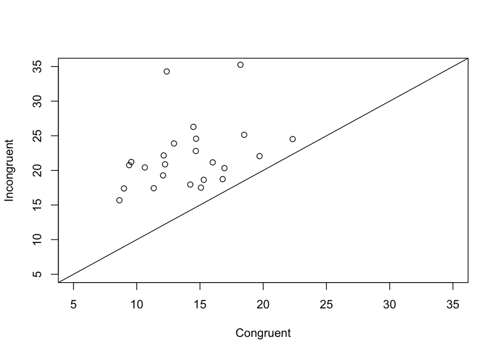

```r
plot(stroop, ylim = c(5,35), xlim = c(5,35))
abline(0,1)
```

Notice that this plot has its x and y axes scaled evenly. Therefore, clustering of the plot around the $45^{\circ}$ line would support $H_0$. Clustering above that line supports $H_A$ where $\mu_i > \mu_c$, and clustering below that line supports $H_A$ where $\mu_i < \mu_c$.

The plot is… suggestive.

### 5. Statistical test

We now apply the test described in Section 2 above.

```r
t.test(stroop$Congruent, stroop$Incongruent, paired=TRUE, conf.level=.95)
```

```
##
##  Paired t-test
##
## data:  stroop$Congruent and stroop$Incongruent
## t = -8.0207, df = 23, p-value = 4.103e-08
## alternative hypothesis: true difference in means is not equal to 0
## 95 percent confidence interval:
##  -10.019028  -5.910555
## sample estimates:
## mean of the differences
##               -7.964792
```

The t value is far outside any critical values we might be interested in, with a p-value that is very close to 0. So, the effect is significant: we do expect $\mu_i > \mu_c$. Our experiment tells us something about linguistic perception and action in people!

Notice that the effect is so strong that an interval with a ridiculously high confidence will still fail to contain a value of 0 for the difference, thus supporting $H_A$.

```r
t.test(stroop$Congruent, stroop$Incongruent, paired=TRUE, conf.level=.99999)
```

```
##
##  Paired t-test
##
## data:  stroop$Congruent and stroop$Incongruent
## t = -8.0207, df = 23, p-value = 4.103e-08
## alternative hypothesis: true difference in means is not equal to 0
## 99.999 percent confidence interval:
##  -13.552037  -2.377546
## sample estimates:
## mean of the differences
##               -7.964792
```

When sampling 24 people across the Incongruent and Congruent cases in the Stroop experiment, we would expect $m_i > m_c$ at least 99.999% of the time.

### 6. Cause

In the final summary of his 1935 paper ‘Studies of Interference in Serial Verbal Reactions’, Stroop says

> The associations that have been [p. 660] formed between the word stimuli and the reading response are evidently more effective than those that have been formed between the color stimuli and the naming response. Since these associations are products of training, and since the difference in their strength corresponds roughly to the difference in training in reading words and naming colors, it seems reasonable to conclude that the difference in speed in reading names of colors and in naming colors may be satisfactorily accounted for by the difference in training in the two activities.

In his original experiment, Stroop also presented uncolored words and just had subjects read them. There was no improvement in time when the words were printed in the congruent color. He therefore concluded that reading is something we’re better trained to do than name colors.

In the incongruent case, Stroop is suggesting that our ‘stronger association’ with reading is interfering with our ability to name colors, something we have a weaker association with.

This is a behaviorist account according to which present behavior is a simple function of conditioning and past experience.

Compelling evidence that this explanation is mistaken is showing that there is no significant difference between, say, expert color identifiers from the art or decorating industry and the general population in the Stroop experiment.